# a1_task1_meuter_claire

Claire Meuter

2023-01-26

```r
knitr::opts_chunk$set(echo = TRUE, message = FALSE, warning = FALSE)
library(tidyverse)
library(here)
library(lubridate)
library(janitor)
library(ggplot2)
```

```r
#read in the data
sierra_amp <- read_csv(here("sierra_amphibians.csv"))
```

#A graph of total mountain yellow-legged frog (Rana muscosa) count each year across all water bodies, by life stage excluding the ‘EggMass’ level. In other words, you should find the total number of adult, subadult, and tadpole yellow-legged frogs observed in the entire study region by life stage and year, but you will not use the lake ID or amphibian_location in your analyses as additional grouping variables. Hint: Convert the date to a date with the {lubridate} package, then pull just the year using the lubridate::year() function…then you can group by year to get counts.

```r
#view class of our date column
class(sierra_amp$survey_date)
```

```
## [1] "character"
```

```r
#this tells me it's a character, but we need it in date format
sierra_amp$survey_date <- mdy(sierra_amp$survey_date)

#Now check out the class again
class(sierra_amp$survey_date)
```

```
## [1] "Date"
```

```r
#cool, now it's in date, so we can use the year function

sierra_amp$survey_date <- year(sierra_amp$survey_date)

#cool, now sierra_amp only has year in survery_date column
```

#Now I’m going to clean the data to only include mountain yellow-legged frog (Rana muscosa) and exclude life stage ‘EggMass’ level

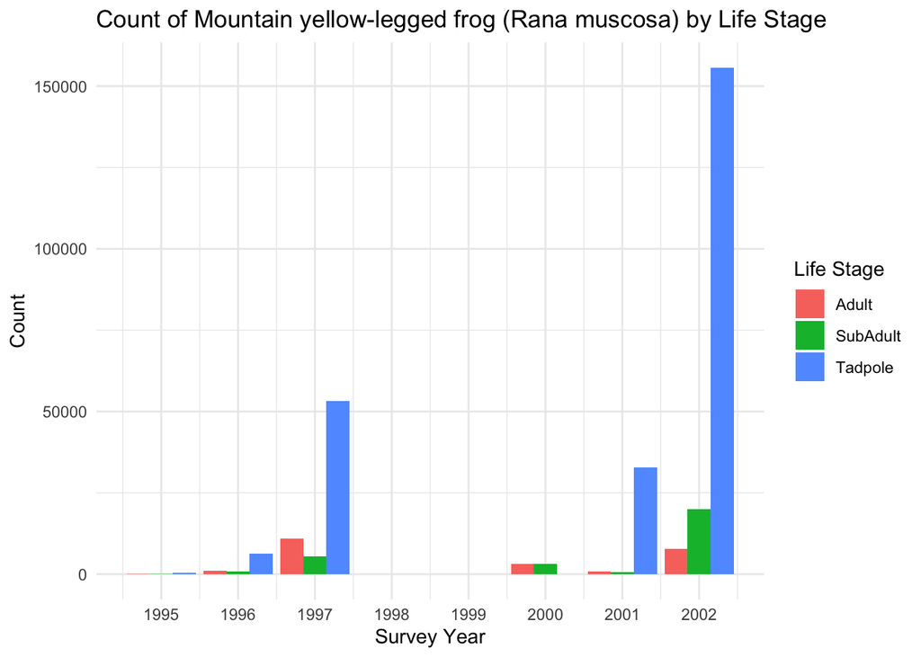

```r
#from reading the metadata I know Rana muscosa is code RAMU

rana_sierra <- sierra_amp %>%
  filter(amphibian_species == "RAMU") %>% #filtering for only RAMU
  filter(amphibian_life_stage != "EggMass") #dropping eggmass


#use group by and summarise_at to find counts
rana_count <- rana_sierra %>%
  group_by(survey_date, amphibian_life_stage) %>%
  summarise_at(vars(amphibian_number), #summing amphibian number column using survey_date and lifestage
               list(count=sum))

#Now I'll make a graph
ggplot(rana_count, aes(fill=amphibian_life_stage, y= count, x=survey_date)) + scale_x_continuous(breaks = seq(from = 1995, to = 2002, by = 1)) + #making x axis annual with every year showing up
    geom_bar(position="dodge", stat="identity") + labs(y = "Count", x = "Survey Year", title = "Count of Mountain yellow-legged frog (Rana muscosa) by Life Stage", fill = "Life Stage") + theme_minimal()
```

### A column graph containing total counts (over all years of the study) of combined adult and subadult endangered mountain yellow-legged frogs (Rana muscosa) observed in the 5 lakes with the greatest total observed counts. In other words, this graph will have at least 5 columns (OK to have more if there are ties), with Lake ID (these aren’t specified in the dataset for confidentiality) as the categorical label on one axis, and total yellow-legged frog counts (adult + subadult counts) in the dataset on the other axis. Make sure they’re in high-to-low or low-to-high order by total yellow-legged frog counts. You should exclude tadpoles for this graph. Note: Consider reformatting the lake ID from just a number to a label like “Lake 10025”), then use fct_reorder to convert it to an ordered factor.

```r
#First I need to do some data wrangling to get my data ready to graph. I can use the rana_sierra dataset. Then I need to exclude tadpoles from the data, make sure survey date is being read as categorical, and reformate if not. Next, I need to sum the amphibian_number by lake_id, and keep the 5 lakes that had to most frog counts.

class(rana_sierra$lake_id)
```

```
## [1] "numeric"
```

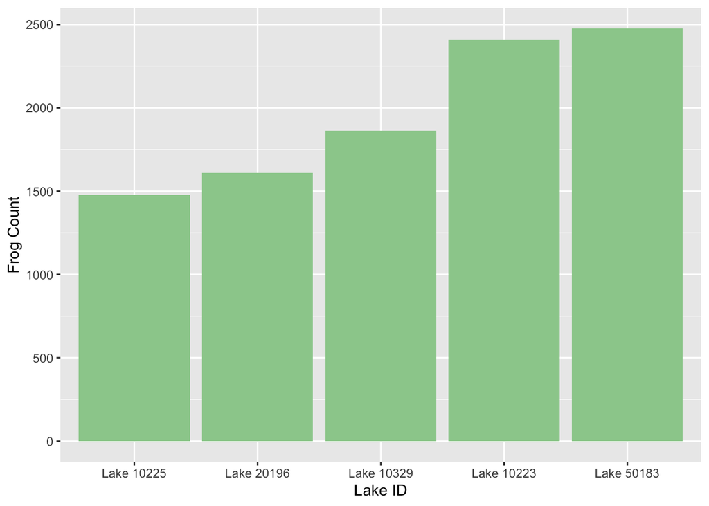

```r
#right now, class of lake_id is numeric, which I'll want to change

#making new dataset
rana_frogs <- rana_sierra %>%
  filter(amphibian_life_stage != "Tadpole") %>% # getting rid of tadpole so only subadult and adult are left
  mutate( lake_id = as.character(lake_id)) %>% #change lake_id to a character class
  group_by(lake_id) %>%
  drop_na() %>%
  summarize_at(vars(amphibian_number), #sum amphibian numbers within lake_id groups
               list(count = sum)) %>%
    slice_max(order_by = count, n = 5) %>% #keep the 5 lakes with highest frog count
    arrange(-count)    #sort the columns by amount of frogs

#renaming the lakes (I know there should be a better way to do this, but couldn't figure out...)
rana_frogs$lake_id[rana_frogs$lake_id == "50183"] <- "Lake 50183"
rana_frogs$lake_id[rana_frogs$lake_id == "10223"] <- "Lake 10223"
rana_frogs$lake_id[rana_frogs$lake_id == "10329"] <- "Lake 10329"
rana_frogs$lake_id[rana_frogs$lake_id == "20196"] <- "Lake 20196"
rana_frogs$lake_id[rana_frogs$lake_id == "10225"] <- "Lake 10225"

#graphing everything
ggplot(rana_frogs, aes(y=count, x = fct_reorder(lake_id, count))) + #fct_reorder allows me to sort the lake_id from least to greatest
  geom_col(fill="darkseagreen3") +
  labs(x= "Lake ID", y = "Frog Count")
```

# Citation

Knapp, R.A., C. Pavelka, E.E. Hegeman, and T.C. Smith. 2020. The Sierra Lakes Inventory Project: Non-Native fish and community composition of lakes and ponds in the Sierra Nevada, California ver 2. Environmental Data Initiative. https://doi.org/10.6073/pasta/d835832d7fd00d9e4466e44eea87fab3